# Children and their heights

s aldridge

24/02/2022

Note: Original code run by S.Aldridge on 24/02/2022. This version was regenerated by M.J.Childs on 22/06/2023.

# Height values

A quick survey to find the outlier range for children’s heights. The following sql scripts extracts all patients under 19 with an alf_e ending in “1” from WLGP table, separating them into measurements that are clearly in m or cm. Note that for this version, counts with < 5 are removed to comply with disclosure policies.

```
SELECT * FROM
          (SELECT age,event_val, count(*) AS counts FROM
                        (SELECT alf_e, floor(DAYS_BETWEEN (event_dt, wob)/365.25) AS age, event_val FROM SAILW1151V.HDR25_BMI_ALG_GP
                        WHERE event_cd
                        IN (SELECT BMI_CODE FROM SAILW1151V.HDR25_BMI_LOOKUP WHERE category = 'height')
                        AND alf_sts_cd IN ('1', '4', '39')
                        AND alf_e like '%1'
                        AND DAYS_BETWEEN (event_dt, wob)/365.25 BETWEEN 0 AND 18
                        AND event_val between 10 and 213
                        )
          GROUP BY age, event_val
          )
        WHERE counts > 5

SELECT * FROM
          (SELECT age,event_val, count(*) AS counts FROM
                        (SELECT alf_e, floor(DAYS_BETWEEN (event_dt, wob)/365.25) AS age, event_val FROM SAILW1151V.HDR25_BMI_ALG_GP
                        WHERE event_cd
                        IN (SELECT BMI_CODE FROM SAILW1151V.HDR25_BMI_LOOKUP WHERE category = 'height')
                        AND alf_sts_cd IN ('1', '4', '39')
                        AND alf_e like '%1'
                        AND DAYS_BETWEEN (event_dt, wob)/365.25 BETWEEN 0 AND 18
                        AND event_val between 0.1 and 2.13)
          GROUP BY age, event_val)
        WHERE counts > 5
```

Below is the raw data generated from these scripts.

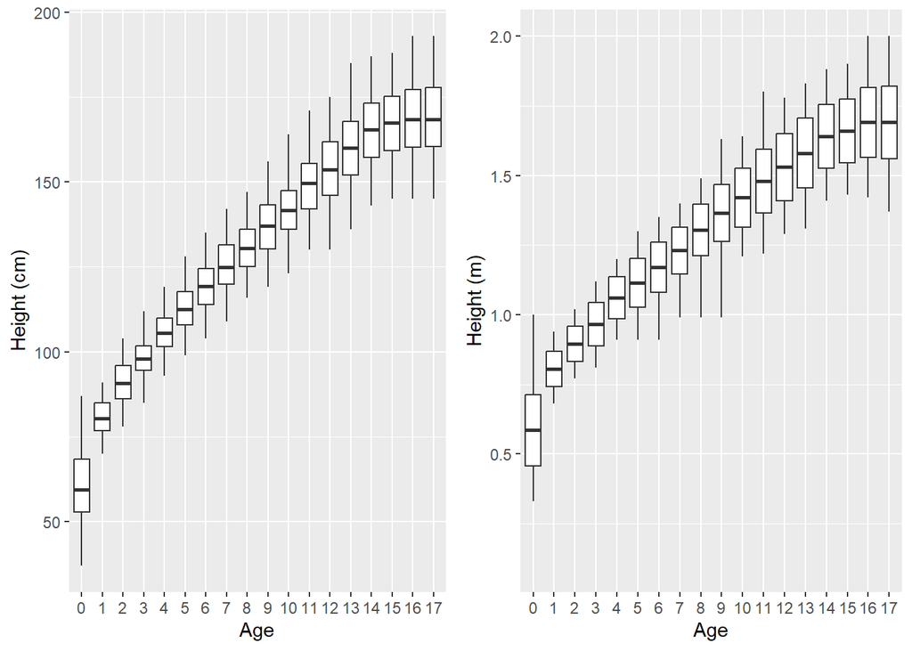

The interquartile range method was used to remove outliers from these results:
$$Q1-1.5*IQR <= x <= Q3+1.5*IQR$$

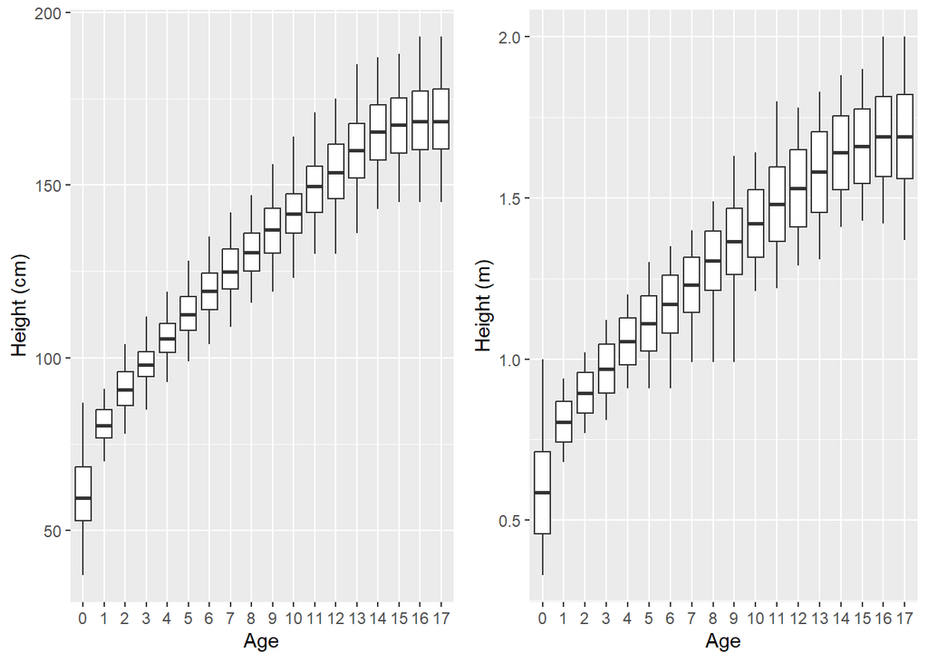

The most extreme values generated by either the m or the cm recordings were used to restrict the heights for the bmi in children algorithm.

# Weight values

A quick survey to find the outlier range for children’s weights. The following sql scripts extracts all patients under 19 with an alf_pe ending in “1” from 1151 WLGP table, separating them into measurements that are clearly in kg or g. Note that for this version, counts with < 5 are removed to comply with disclosure policies. As a result, we are unable to show the raw data for the second script.

```
SELECT * FROM
          (SELECT age,event_val, count(*) AS counts FROM
                        (SELECT alf_e, floor(DAYS_BETWEEN (event_dt, wob)/365.25) AS age, event_val FROM SAILW1151V.HDR25_BMI_ALG_GP
                        WHERE event_cd
                        IN (SELECT BMI_CODE FROM SAILW1151V.HDR25_BMI_LOOKUP WHERE category = 'weight')
                        AND alf_sts_cd IN ('1', '4', '39')
                        AND alf_e like '%1'
                        AND DAYS_BETWEEN (event_dt, wob)/365.25 BETWEEN 0 AND 18
                        AND event_val between 0 and 300
                        )
          GROUP BY age, event_val
          )
        WHERE counts > 5

SELECT * FROM
          (SELECT age,event_val, count(*) AS counts FROM
                        (SELECT alf_e, floor(DAYS_BETWEEN (event_dt, wob)/365.25) AS age, event_val FROM SAILW1151V.HDR25_BMI_ALG_GP
                        WHERE event_cd
                        IN (SELECT BMI_CODE FROM SAILW1151V.HDR25_BMI_LOOKUP WHERE category = 'weight')
                        AND alf_sts_cd IN ('1', '4', '39')
                        AND alf_e like '%1'
                        AND DAYS_BETWEEN (event_dt, wob)/365.25 BETWEEN 0 AND 1
                        AND event_val between 1000 and 10000)
          GROUP BY age, event_val)
        WHERE counts > 5
```

Below is the raw data generated from these scripts.

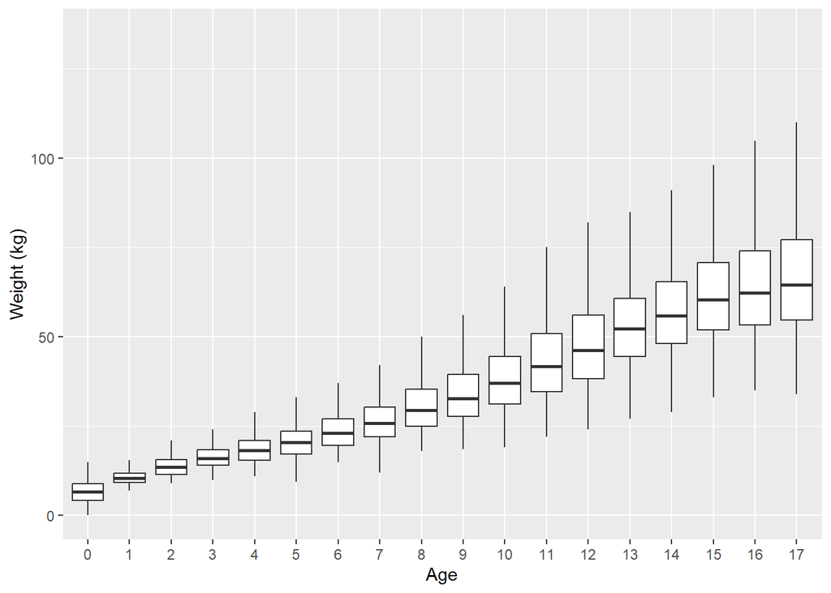

The interquartile range method was used to remove outliers from these results:
$$Q1-1.5*IQR <= x <= Q3+1.5*IQR$$

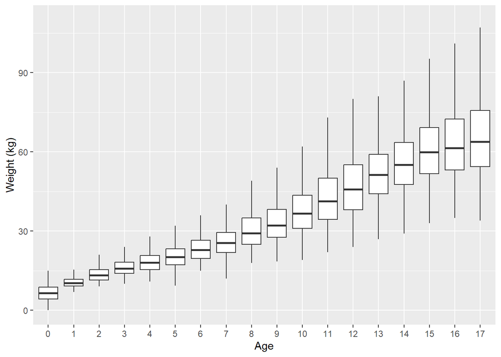

The most extreme values generated by either the kg or g recordings were used to restrict the heights for the bmi in children algorithm.